# c7w1q1

Robert Handsfield

04/12/2015

# Question 1

Consider the data set given below

```r
x <- c(0.18, -1.54, 0.42, 0.95)
```

And weights given by

```r
w <- c(2, 1, 3, 1)
```

Give the value of $\mu$ that minimizes the least squares equation $\sum_{i=1}^n{w_i(x_i-\mu)^2}$

1. **0.1471**
2. 0.300
3. 1.077
4. 0.0025

## Solution

Use

```r
# finishes with errors
lm(x~x, weights=w);
```

```
##
## Call:
## lm(formula = x ~ x, weights = w)
##
## Coefficients:
## (Intercept)
##      0.1471
```

```r
#Or, plug each answer into sum(w*(x-u)^2)
sum(w*(x-.1471)^2);
```

```
## [1] 3.716543
```

```r
sum(w*(x-.3)^2);
```

```
## [1] 3.8801
```

```r
sum(w*(x-1.077)^2);
```

```
## [1] 9.768983
```

```r
sum(w*(x-.0025)^2);
```

```
## [1] 3.862994
```

**Answer 1:** 0.1471

# Question 2

Consider the following data set

```r
x <- c(0.8, 0.47, 0.51, 0.73, 0.36, 0.58, 0.57, 0.85, 0.44, 0.42)
y <- c(1.39, 0.72, 1.55, 0.48, 1.19, -1.59, 1.23, -0.65, 1.49, 0.05)
```

Fit the regression through the origin and get the **slope** treating y as the outcome and x as the regressor. (Hint, do not center the data since we want regression through the origin, not through the means of the data.)

**Slope = ?**

1. 0.59915
2. -0.04462
3. -1.713
4. **0.8263**

## Solution

Use $\hat{\beta_1} = { {\sum_{i=1}^{n}Y_i X_i} \over {\sum_{i=1}^{n}X_i^2} }$

```r
sum(x*y)/sum(x^2);
```

```
## [1] 0.8262517
```

**Answer 2:** 0.8263

# Question 3

Do `data(mtcars)` from the datasets package and fit the regression model with mpg as the outcome and weight as the predictor. Give the **slope coefficient**.

1. **-5.344**
2. -9.559
3. 0.5591
4. 30.2851

## Solution

```r
data(mtcars);

# X = wt, Y = mpg; form is lm(y~x, ...)
lm(formula = mpg ~ wt, data=mtcars);
```

```
##
## Call:
## lm(formula = mpg ~ wt, data = mtcars)
##
## Coefficients:
## (Intercept)           wt
##      37.285       -5.344
```

**Answer 3:** -5.344

# Question 4

Consider data with an outcome (Y) and a predictor (X). The standard deviation of the predictor is one half that of the outcome. The correlation between the two variables is .5. What value would the **slope coefficient** be for the regression model with Y as the outcome and X as the predictor?

1. 0.25
2. **1**
3. 3
4. 4

## Solution

$Sd(X) = {Sd(Y) \over 2}$

$Cor(Y,X) = 0.5$

$\hat{\beta_1} = ?$

Use  
$\hat{\beta_1} = Cor(Y,X) \cdot { {Sd(Y)} \over {Sd(X)} }$

$\therefore$

$\hat{\beta_1} = 0.5 * {2Sd(X) \over Sd(X)} = 0.5 * 2 = 1$

**Answer 4:** 1

# Question 5

Students were given two hard tests and scores were normalized to have empirical mean 0 and variance 1. The correlation between the scores on the two tests was 0.4. What would be the **expected score on Quiz 2** for a student who had a normalized score of 1.5 on Quiz 1?

1. 0.16
2. 0.4
3. 1.0
4. **0.6**

## Solution

If sets are normalized, then $Y_i = X_i * Cor(X,Y)$

- $X_i$ = 1.5
- $Cor(X,Y)$ = 0.4
- $Y_i$ = ?

```r
1.5 * 0.4;
```

```
## [1] 0.6
```

**Answer 5:** 0.6

# Question 6

Consider the data given by the following

```r
x <- c(8.58, 10.46, 9.01, 9.64, 8.86)
```

What is the value of the **first measurement** if x were normalized (to have mean 0 and variance 1)?

1. **-0.9719**
2. 8.58
3. 9.31
4. 8.86

## Solution

Normalize data by centering, then scaling: $Z_i= {{X_i−\bar{X}} \over S}$

```r
z <- ( (x - mean(x)) / sd(x) );

z;
```

```
## [1] -0.9718658  1.5310215 -0.3993969  0.4393366 -0.5990954
```

**Answer 6:** -0.9719

# Question 7

Consider the following data set (used for question 2 as well). What is the **intercept** for fitting the model with x as the predictor and y as the outcome?

```r
x <- c(0.8, 0.47, 0.51, 0.73, 0.36, 0.58, 0.57, 0.85, 0.44, 0.42)
y <- c(1.39, 0.72, 1.55, 0.48, 1.19, -1.59, 1.23, -0.65, 1.49, 0.05)
```

1. **1.567**
2. 2.105
3. 1.252
4. -1.713

## Solution

Use

$\hat{\beta_1} = Cor(Y,X) \cdot { {Sd(Y)} \over {Sd(X)} }$ and $\hat{\beta_0} = \bar{Y} - \hat{\beta_1}\bar{X}$

```r
ym <- mean(y); xm <- mean(x);
ys <- sd(y); xs <- sd(x);

b0 <- ym - (cor(x,y)*ys/xs) * xm;

print(b0); print(lm(y~x));
```

```
## [1] 1.567461
```

```
##
## Call:
## lm(formula = y ~ x)
##
## Coefficients:
## (Intercept)            x
##       1.567       -1.713
```

Answers check out.

**Answer 7:** 1.567

# Question 8

You know that both the predictor and response have mean 0. What can be said about the intercept when you fit a linear regression?

1. **It must be identically 0.**
2. Nothing about the intercept can be said from the information given.
3. It is undefined as you have to divide by zero.
4. It must be exactly one.

## Solution

By definition, the regression line goes through the mean values of both vectors

X and Y both having mean 0 means they have been centered by subtracting the means: $\tilde{X} = X_i - \bar{X}$

The centering moves the origin $\{0,0\}$ to the middle of the plot, and the best linear fit line will go right through it.

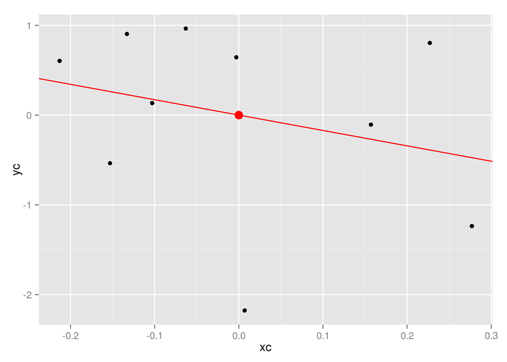

```r
library("ggplot2");

x <- c(0.8, 0.47, 0.51, 0.73, 0.36, 0.58, 0.57, 0.85, 0.44, 0.42);
y <- c(1.39, 0.72, 1.55, 0.48, 1.19, -1.59, 1.23, -0.65, 1.49, 0.05);

xc <- x-mean(x);
yc <- y-mean(y);

ggplot() + aes(xc,yc) + geom_point() +
    geom_point(aes(x=0,y=0), color="red", size=4) +
    geom_abline(aes(intercept = coef(lm(yc~xc))[1], slope = coef(lm(yc~xc))[2]), color="red");
```

```r
round(coef(lm(yc~xc)), 3);
```

```
## (Intercept)          xc
##       0.000      -1.713
```

**Answer 8:** The intercept must be identically 0

# Question 9

Consider the data given by

```r
x <- c(0.8, 0.47, 0.51, 0.73, 0.36, 0.58, 0.57, 0.85, 0.44, 0.42)
```

What value minimizes the sum of the squared distances between these points and itself?

1. **0.573**
2. 0.8
3. 0.36
4. 0.44

## Solution

For $\sum_{i=1}^{n}(X_i - \mu)^2$, the minimizing value is the sample mean: $\mu_{min} = \bar{X}$

```r
mean(x);
```

```
## [1] 0.573
```

**Answer 9:** 0.573

# Question 10

Let the *slope* having fit Y as the outcome and X as the predictor be denoted as $\beta_1$. Let the slope from fitting X as the outcome and Y as the predictor be denoted as $\gamma_1$. Suppose that you divide $\beta_1$ by $\gamma_1$; in other words consider $\beta_1 / \gamma_1$. What is this ratio always equal to?

1. **Var(Y)/Var(X)**
2. 2SD(Y)/SD(X)
3. 1
4. Cor(Y,X)

## Solution

Use $\hat{\beta_1} = Cor(Y,X) \cdot { {Sd(Y)} \over {Sd(X)} }$

${\beta_1 \over \gamma_1} = Cor(Y,X) \cdot { {Sd(Y)} \over {Sd(X)} } \div Cor(X,Y) \cdot { {Sd(X)} \over {Sd(Y)}}$

by $Cor(Y,X) = Cor(X,Y). . .$

${\beta_1 \over \gamma_1} = { {Sd(Y)} \over {Sd(X)} } \div { {Sd(X)} \over {Sd(Y)} } = { {Sd(Y)} \over {Sd(X)}} \cdot { {Sd(Y)} \over {Sd(X)}}$

$\therefore {\beta_1 \over \gamma_1} = {Var(Y) \over Var{(X)}}$

Verify this

```r
x <- c(0.8, 0.47, 0.51, 0.73, 0.36, 0.58, 0.57, 0.85, 0.44, 0.42);
y <- c(1.39, 0.72, 1.55, 0.48, 1.19, -1.59, 1.23, -0.65, 1.49, 0.05);

# beta1
beta1 <- coef(lm(y~x))[2];

# gamma1
gamma1 <- coef(lm(x~y))[2];

beta1 / gamma1;
```

```
##        x
## 38.39077
```

```r
# answer a
var(y) / var(x); # <-- this is it
```

```
## [1] 38.39077
```

```r
# answer b
2*sd(y)/sd(x)
```

```
## [1] 12.39206
```

```r
# answer c
1;
```

```
## [1] 1
```

```r
# answer d
cor(x,y);
```

```
## [1] -0.2764425
```

**Answer 10:** var(y) / var(x)